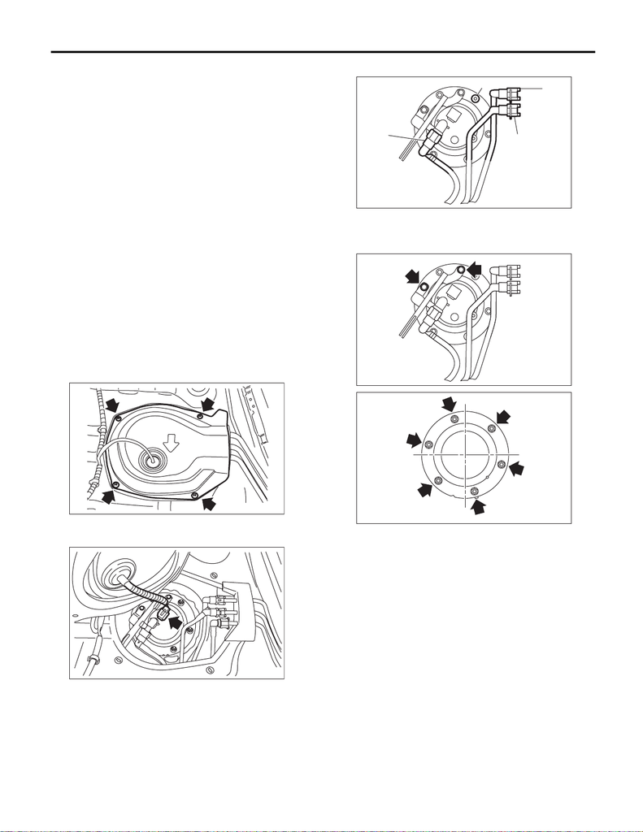

FU(STI)-85

Fuel Sub Level Sensor

FUEL INJECTION (FUEL SYSTEMS)

31.Fuel Sub Level Sensor

A: REMOVAL

WARNING:

Place “NO OPEN FLAMES” signs near the

working area.

CAUTION:

• Be careful not to spill fuel.

• Catch the fuel from the tubes using a contain-

er or cloth.

• If the fuel gauge indicates that two thirds or

more of the fuel is remaining, be sure to drain

fuel before starting work to avoid the fuel to

spill.

1) Release the fuel pressure. <Ref. to FU(STI)-64,

RELEASING OF FUEL PRESSURE, PROCE-

DURE, Fuel.>

2) Drain fuel. <Ref. to FU(STI)-64, DRAINING

FUEL (WITH SUBARU SELECT MONITOR),

PROCEDURE, Fuel.>

3) Disconnect the ground cable from battery.

4) Remove the rear seat cushion. <Ref. to SE-29,

REMOVAL, Rear Seat.>

5) Remove the service hole cover.

6) Disconnect the connector from the fuel sub level

sensor.

7) Disconnect the quick connectors of fuel delivery

tube (A), fuel return tube (B), and jet pump tube (C).

<Ref. to FU(STI)-94, REMOVAL, Fuel Delivery,

Return and Evaporation Lines.>

8) Remove the rubber cap (D) from the nut.

9) Remove the bolts and nuts which hold fuel sub

level sensor protector and fuel sub level sensor up-

per plate to the fuel tank.

10) Remove the fuel sub level sensor from the fuel

tank.

FU-08307

FU-08308

FU-08309

(B)

(C)

(A)

(D)

FU-08397

FU-04569

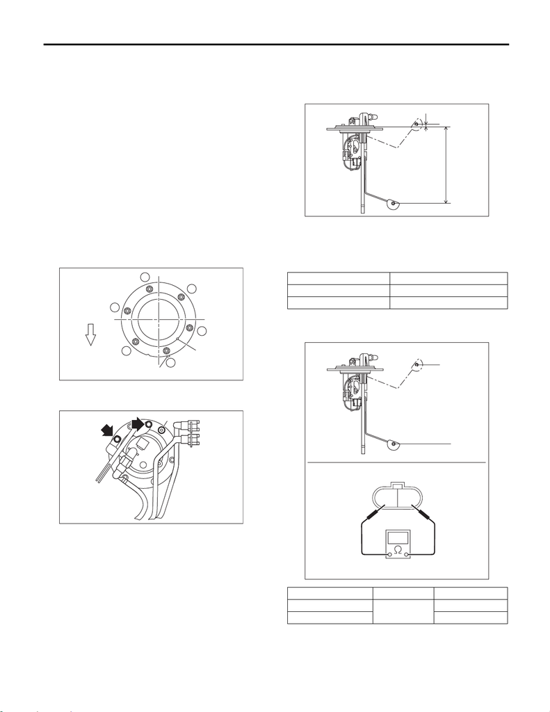

FU(STI)-86

Fuel Sub Level Sensor

FUEL INJECTION (FUEL SYSTEMS)

B: INSTALLATION

Install in the reverse order of removal while being

careful of the following.

• Make sure the sealing portion is free from fuel or

foreign matter before installation.

• Align protrusion (A) of the gasket to the position

shown in the figure.

• Align protrusion (B) of the fuel sub level sensor to

the cutout in the fuel sub level sensor upper plate.

• Tighten the nuts and bolts to the specified torque

in the order as shown in the figure.

• After tightening, install the rubber cap (C) at the

position shown in the figure.

NOTE:

• Use a new gasket.

• Do not forget to install rubber cap (C).

Tightening torque:

4.4 N·m (0.4 kgf-m, 3.2 ft-lb)

C: INSPECTION

1) Check that the fuel sub level sensor has no dam-

age.

2) Measure the fuel sub level sensor float position.

3) Measure the resistance between fuel sub level

sensor terminals.

(a) Front side of vehicle

FU-04533

1

6

5

2

4

3

(B)

(A)

(a)

FU-08398

(C)

(1) FULL

(2) EMPTY

(3) Datum points

Float position Standard

FULL to Datum point (A) 5.31±3.5 mm (0.209±0.138 in)

EMPTY to Datum point (B) 160.6±3.5 mm (6.323±0.138 in)

Float position Terminal No. Standard

FULL (A)

1 and 2

8.7±1.0 Ω

EMPTY (B) 270.9±4.0 Ω

(1)

(B)

(2)

(A)

FU-04213

(3)

FU-04214

21

(B)

(A)